# Rage against the Machine Learning?

KI zwischen Mythos und Fabel(haft)

Jonas Stettner | CorrelAid @ CDL

9. Oktober 2026

# Intro

## Social Responsibility: Wer sollte uns als Beispiel dienen?

- Peter Thiel erhielt Axel Springer Award: oft als Demokratiepreis bezeichnet
- Geht an Persönlichkeiten, die „[…] **gesellschaftliche Verantwortung übernehmen**“
  - Andere Personen, die gesellschaftliche Verantwortung übernehmen: Jeff Bezos (2018) · Elon Musk (2020) · Sam Altman (2025)
- Wie man gesellschaftliche Verantwortung übernimmt:

> *„If you’re evil, you’re at least competent. And if you’re evil, you’re not bad, and therefore you’re actually maybe kind of good because you’re at least getting something done.“*

Axel Springer SE (o. J.); von Boeselager (2026); Firth (2026)

## Getting something done responsibly with artificial superintelligence

- Wie können wir KI in der Zivilgesellschaft verantwortungsvoll nutzen?
- Spannungsfeld:
  - KI ist durch die Umstände ihrer Herstellung und Verwendung nicht nur ein Werkzeug, sondern (inhärent) politisch und hat externalisierte Kosten
  - Von konkreten Problemen ausgehend kann KI als Werkzeug manchmal die beste Option sein

Keymolen & van der Haak (2026)

# Wer entwickelt KI?

## Peter Thiel, der Antichrist und der “Grey Tribe”

- Thiel vertritt eine politische Theologie mit dem Antichristen als zentraler Figur
  - verspricht Frieden, Sicherheit und Einheit, z.B. durch **Multilateralismus, internationale Regulierung, interreligiösen Dialog**
  - will aber in Wahrheit Weltherrschaft erlangen und Fortschritt aufhalten
- **Red Tribe** (konservativ) · **Blue Tribe** (progressiv) · **Grey Tribe** (Tech, **Akzelerationismus**)
  - Blue = Regulierung, Institutionen = Thiels „Antichrist“
  - Wie kann man Blue bekämpfen? **Balaji Srinivasan**: Grey sollte sich mit Red gegen Blue verbünden

Alexander (2014); Duran (2024); Andreessen (2023); Brian & Heeps (2026); Thiel & Wolfe (2026)

## Nicht das letzte Abendmahl

[figure not shown]

[figure not shown]

[figure not shown]

Oben: (Rozen & Holland, 2026) · Unten links: (Trump, 2026) · Unten rechts: (Leonardo da Vinci, 1494–1498)

# Entzauberung: Was ist KI eigentlich?

## KI-Begriff: Intelligenz

> Intelligence is the computational part of the ability to achieve goals in the world. […] Intelligence involves mechanisms, and **AI research has discovered how to make computers carry out some of them and not others**. Such programs should be considered “somewhat intelligent”. (McCarthy, 2007)
- Intelligenz als auf ein Ziel gerichtete Fähigkeit, die unterschiedliche Komponenten umfasst (z.B. von Logik bis Erkennen von Objekten)

## KI als Oberbegriff

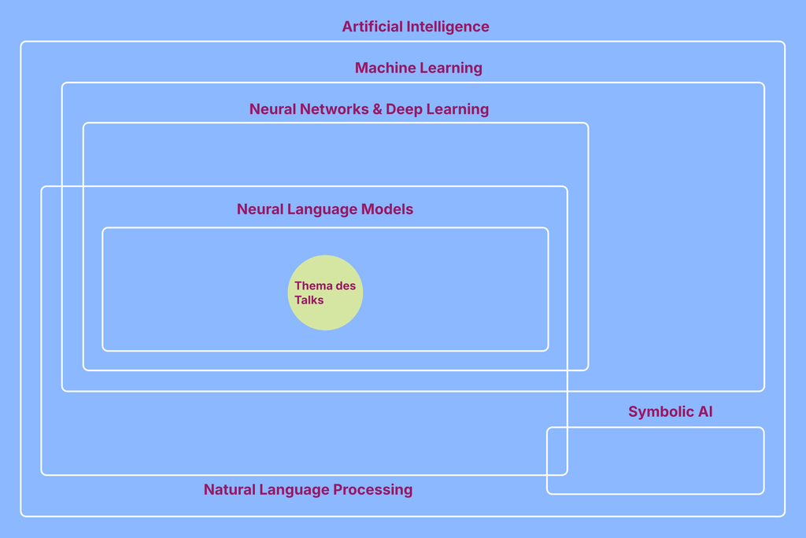

# Externalisierte Kosten

## Warum muss KI überhaupt reguliert werden?

- Neuronale Netzwerke
  - brauchen viele Trainingsdaten und Rechenkapazitäten
  - Output nicht erklärbar

**Ökologisch**

- **Strom & CO₂:** 2030 mehr als ganz Japan
- **Wasser:** 2025 so viel wie alles Flaschenwasser weltweit

**Gesellschaftlich**

- Machtkonzentration
- Diskriminierung
- Ausbeutung (Klickarbeit)
- Cognitive Outsourcing

International Energy Agency (2025); International Energy Agency (2026); de Vries-Gao (2025); Kak & Myers West (2023); Buolamwini & Gebru (2018); Williams et al. (2022); Perrigo (2023); Jose et al. (2025)

## Auswirkungen von KI auf die Zivilgesellschaft

- KI-Zusammenfassungen und Chatbots
  - Website-Traffic verringert sich drastisch
  - Weniger Kontrolle darüber, wie Informationen Menschen erreichen
- Einfluss auf soziale Beratungsangebote
  - Chatbots werden vermehrt als Berater genutzt
  - Ratsuchende von Chatbot-Sessions beeinflusst
- Ökonomische Zwänge
  - KI steht für Effizienzsteigerung
  - Workslop

Chapekis & Lieb (2025); Augustin (2025); Niederhoffer et al. (2025)

# KI als Werkzeug wofür?

## KI-Tasks

- KI-Methoden werden für Tasks entwickelt und mit für diese zusammengestellten Daten und Metriken evaluiert und verglichen
- Beispiele Tasks: Klassifikation, Textzusammenfassung, Nutzung von Tools
- Einfachste Metrik: Accuracy (Anteil richtiger Klassifikationen)
- Neuronale Netzwerke erzielen beste Performance bei vielen Tasks, bzw. ermöglichen erst manche Tasks (LeCun et al., 2015)

## Abschied von Tasks? - “Große” Neuronale Sprachmodelle

- BERT -> Bidirectional encoder representations from transformers (340 Millionen Parameter) (Devlin et al., 2019)
  - Finetuning: Anpassung des Modells und Parameter auf Task
- Claude Mythos oder Fable (generative Modelle) -> Parameterzahl nicht offengelegt; Schätzungen im Bereich mehrerer Billionen
  - In-Context Learning (ICL) und (Few Shot) Prompting -> Keine Veränderung der Parameter (Brown et al., 2020)
- „Aufklärung schlägt in Mythologie zurück“ (Horkheimer & Adorno, 1947)

# KI zwischen Mythos und Fabel(haft)

## KI als Mythos

- Bessere Informationsarchitektur statt eigener Chatbot
- Ehrenamtlich Tätige würden KI lieber für Verwaltungstätigkeiten als für Social Media einsetzen
- Prompt Engineering: “You are a senior air traffic controller, take over routing planes for this airport”
- KI als Tech-Fix
  - KI wird als Lösung für Probleme vorgeschlagen, aber das eigentliche Problem wird nicht gelöst (Chatbot gegen Einsamkeit)
- Manchmal reicht Prozessoptimierung statt Agentic AI

Civic Data Lab (2026a); Zheng et al. (2024); Morozov (2013)

## KI: Fabel(haft)

- CDL Projekte
  - AWO Demokratieförderquote: Klassifikation von Förderprogrammen
  - Schule ein Gesicht geben: Semantische Suche (Informationen mit eigenen Worten finden)
  - genialsozial: Texterkennung bei handschriftlich ausgefüllten Formularen
- AfD-Gutachten: Vorfiltern (Klassifikation) von Äußerungen von AfD-Politiker:innen

Civic Data Lab (2026b); Benamor (2026)

# How to: Rage against the Machine Learning

- Im Kopf behalten, dass Big Tech aktiv eine fragwürdige politische Agenda verfolgt
- Thiels „Antichrist“ sein:
  - Regulierung und demokratische Institutionen verteidigen statt „move fast and break things“
- Weniger *„Wie können wir KI einsetzen?“*, mehr *„Welches Problem haben wir (wirklich) und ist KI dafür die beste Lösung?“*
- Mitdenken: *„Wozu – und zu welchem Preis?“*
- Mehr konkrete Handlungsempfehlungen für Zivilgesellschaft: Code of Conduct Demokratische KI (demokratische-ki.de)

# Zeit für Nachfragen und Gedanken

## Quellen

Alexander, S. (2014, September 30). *I Can Tolerate Anything Except the Outgroup*. Slate Star Codex. https://slatestarcodex.com/2014/09/30/i-can-tolerate-anything-except-the-outgroup/

Andreessen, M. (2023, Oktober 16). *The Techno-Optimist Manifesto*. Andreessen Horowitz. https://a16z.com/the-techno-optimist-manifesto/

Augustin, M. (2025). KI-assoziierte Psychose: Erkenntnisse aus ersten Fällen. *Der Nervenarzt*, *96*(7), 699–701. https://doi.org/10.1007/s00115-025-01909-4

Axel Springer SE. (o. J.). *Über den Award*. https://www.axelspringer.com/de/axel-springer-award/ueber-den-award

Benamor, S. (2026, Juli 23). *Grenzen der Verbotsprognose: Über Chancen und Grenzen von Gutachten zur Verfassungswidrigkeit der AfD*. Verfassungsblog. https://verfassungsblog.de/grenzen-der-verbotsprognose/

Brian, A., & Heeps, E. (2026, Februar 6). *Right-wing billionaire Peter Thiel gives ’antichrist’ lecture in Cambridge*. Varsity. https://www.varsity.co.uk/news/31135

Brown, T. B., Mann, B., Ryder, N., Subbiah, M., Kaplan, J., et al. (2020). Language Models are Few-Shot Learners. *Advances in Neural Information Processing Systems*, *33*, 1877–1901.

Buolamwini, J., & Gebru, T. (2018). Gender Shades: Intersectional Accuracy Disparities in Commercial Gender Classification. *Proceedings of the 1st Conference on Fairness, Accountability and Transparency*, *81*, 77–91.

Chapekis, A., & Lieb, A. (2025, Juli 22). *Google users are less likely to click on links when an AI summary appears in the results*. Pew Research Center. https://www.pewresearch.org/short-reads/2025/07/22/google-users-are-less-likely-to-click-on-links-when-an-ai-summary-appears-in-the-results/

Civic Data Lab. (2026a, August 17). *KI im Ehrenamt – Auswertung einer Umfrage mit digital verein(t)*. Civic Data Lab. https://civic-data.de/machen/begleitete-projekte/ki-im-ehrenamt-auswertung-einer-umfrage/

Civic Data Lab. (2026b, August 17). *K(l)ein Geld für Demokratie?! – Demokratieförderquote*. Civic Data Lab. https://civic-data.de/machen/begleitete-projekte/demokratiefoerderquote/

de Vries-Gao, A. (2025). The carbon and water footprints of data centers and what this could mean for artificial intelligence. *Patterns*. https://doi.org/10.1016/j.patter.2025.101430

Devlin, J., Chang, M.-W., Lee, K., & Toutanova, K. (2019). BERT: Pre-training of Deep Bidirectional Transformers for Language Understanding. *Proceedings of the 2019 Conference of the North American Chapter of the Association for Computational Linguistics (NAACL-HLT)*, 4171–4186. https://doi.org/10.18653/v1/N19-1423

Duran, G. (2024, April 26). *The Tech Baron Seeking to Purge San Francisco of „Blues“*. The New Republic.

Firth, N. (2026, September 28). *The Download: Rogue agent liability and the AI Hype Index*. MIT Technology Review. https://www.technologyreview.com/2026/09/28/1145202/the-download-rogue-agent-liability-and-the-ai-hype-index/

Horkheimer, M., & Adorno, T. W. (1947). *Dialektik der Aufklärung: Philosophische Fragmente*. Querido.

International Energy Agency. (2025). *Energy and AI*. IEA. https://www.iea.org/reports/energy-and-ai

International Energy Agency. (2026). *Key Questions on Energy and AI*. IEA. https://www.iea.org/

Jose, B., Joseph, D., Mohan, V., Alexander, E., Varghese, S. K., & Roy, A. (2025). Outsourcing cognition: The psychological costs of AI-era convenience. *Frontiers in Psychology*, *16*, 1645237. https://doi.org/10.3389/fpsyg.2025.1645237

Kak, A., & Myers West, S. (2023). *AI Now 2023 Landscape: Confronting Tech Power*. AI Now Institute. https://ainowinstitute.org/2023-landscape

Keymolen, E., & van der Haak, D. (2026). Artificial intentions: Winner’s inherently political artifacts, AI and government. In A. Fox & D. Cressman (Hrsg.), *Arrangements of power: Tracing Langdon Winner’s legacy within and beyond the philosophy of technology*. Springer. https://doi.org/10.1007/978-3-032-17371-3_2

LeCun, Y., Bengio, Y., & Hinton, G. (2015). Deep learning. *Nature*, *521*(7553), 436–444. https://doi.org/10.1038/nature14539

Leonardo da Vinci. (1494–1498). *Das Abendmahl*. Wikimedia Commons. https://commons.wikimedia.org/wiki/File:Last_Supper_by_Leonardo_da_Vinci.jpg

McCarthy, J. (2007, November 12). *What is Artificial Intelligence?* Stanford University. http://jmc.stanford.edu/articles/whatisai/whatisai.pdf

Morozov, E. (2013). *To Save Everything, Click Here: The Folly of Technological Solutionism*. PublicAffairs.

Niederhoffer, K., Kellerman, G. R., Lee, A., Liebscher, A., Rapuano, K., & Hancock, J. T. (2025, September 22). *AI-Generated „Workslop“ Is Destroying Productivity*. Harvard Business Review. https://hbr.org/2025/09/ai-generated-workslop-is-destroying-productivity

Perrigo, B. (2023, Januar 18). *Exclusive: OpenAI Used Kenyan Workers on Less Than $2 Per Hour to Make ChatGPT Less Toxic*. TIME. https://time.com/6247678/openai-chatgpt-kenya-workers/

Rozen, C., & Holland, S. (2026, September 29). *Trump, AI CEOs sign voluntary safety pact, back data center expansion*. Reuters. https://www.reuters.com/legal/government/trump-host-zuckerberg-anthropics-amodei-other-ai-titans-tuesday-2026-09-29/

The National News Desk. (2026, September 29). *Trump signs executive order to replace ’artificial intelligence’ with ’super intelligence’*. The National News Desk. https://wjla.com/news/nation-world/trumps-executive-order-replaces-artificial-intelligence-with-super-intelligence-china-industrial-revolution-industry-elon-musk-mark-zuckerberg-politics-president-donald-trump

Thiel, P., & Wolfe, S. (2026, Juli 15). *The pope and the antichrist*. First Things. https://firstthings.com/the-pope-and-the-antichrist/

Trump, D. (2026, April 12). *KI-generiertes Bild von Donald Trump als Jesus Christus*. Truth Social; Wikimedia Commons. https://commons.wikimedia.org/wiki/File:AI-Generated_Image_depicting_Donald_Trump_as_Jesus_Christ.jpg

von Boeselager, M. (2026, September 25). *Peter Thiel erhält Axel Springer Award – und kann verstehen, warum Berliner die Linke wählen*. DER SPIEGEL. https://www.spiegel.de/kultur/peter-thiel-erhaelt-axel-springer-award-und-kann-verstehen-warum-berliner-die-linke-waehlen-a-9c2ee2fc-5bfb-4d4c-b64d-dfaeb57ff7d4

Williams, A., Miceli, M., & Gebru, T. (2022, Oktober 13). *The Exploited Labor Behind Artificial Intelligence*. Noema Magazine. https://www.noemamag.com/the-exploited-labor-behind-artificial-intelligence/

Zheng, M., Pei, J., Logeswaran, L., Lee, M., & Jurgens, D. (2024). When "A Helpful Assistant" Is Not Really Helpful: Personas in System Prompts Do Not Improve Performances of Large Language Models. *Findings of the Association for Computational Linguistics: EMNLP 2024*.